# Sheet 3

- Anna Bütfering
- Lea Neumann
- Juan Provencio

## Task 1

Two moons with an invertible neural network

```python
import math
import torch
import torch.nn as nn
import torch.optim as optim
import torch.nn.functional as F
from torch.utils.data import DataLoader, TensorDataset
import numpy as np
from sklearn.datasets import make_moons
import matplotlib.pyplot as plt
from sklearn.model_selection import train_test_split
from tqdm import tqdm
## Plot options
from cycler import cycler
from matplotlib import rcParams
rcParams['axes.grid'] = True
rcParams['grid.linestyle'] = '--'
rcParams['grid.alpha'] = 0.5
rcParams['axes.labelsize'] = 20
rcParams['axes.prop_cycle'] = cycler('color', ['#C61A27', '#3891A6', \
                                               '#F79D65', '#FDE74C', \
                                                '#9BC53D', '#5BC0EB',
                                                '#E55934', '#FA7921',
                                                '#8D230F', '#1B998B'])
colors = rcParams['axes.prop_cycle'].by_key()['color']
rcParams['axes.titlesize'] = 22
#rcParams['figure.figsize'] = (12, 7)
rcParams['figure.titlesize'] = 26
rcParams['font.size'] = 16
rcParams['image.cmap'] = 'magma'
rcParams['lines.markeredgewidth'] = 2
rcParams['lines.markerfacecolor'] = 'white'
rcParams['markers.fillstyle'] = 'none'
# Define textbox style for plots
textbox_style = dict(boxstyle='round', facecolor='white', alpha=0.8, edgecolor='black')

X, _ = make_moons(n_samples=2000, noise=0.1)
X = torch.tensor(X, dtype=torch.float32)

# train-test split
X_train, X_test = train_test_split(X, test_size=0.2, shuffle=True)

print("Train size:", X_train.shape)
print("Test size:", X_test.shape)
```

```
Train size: torch.Size([1600, 2])
Test size: torch.Size([400, 2])
```

```python
# Coupling Layer for RealNVP with forward and inverse methods
class CouplingLayer(nn.Module):
    def __init__(self, input_size, hidden_size, mask):
        """
        input_size : dimension of x (2 for two moons)
        hidden_size : width of the internal networks
        mask : boolean tensor of shape (input_size,)
               True  -> passthrough part (x1)
               False -> transformed part (x2)
        """
        super().__init__()
        self.mask = mask
        #print("Mask shape:", self.mask.shape)

        in_dim = int(mask.sum().item())
        out_dim = input_size - in_dim  # number of transformed dims

        # translation
        self.t_net = nn.Sequential(
            nn.Linear(in_dim, hidden_size),
            nn.ReLU(),
            nn.Linear(hidden_size, hidden_size),
            nn.ReLU(),
            nn.Linear(hidden_size, out_dim)
        )

        # scaling
        self.s_net = nn.Sequential(
            nn.Linear(in_dim, hidden_size),
            nn.ReLU(),
            nn.Linear(hidden_size, hidden_size),
            nn.ReLU(),
            nn.Linear(hidden_size, out_dim)
        )

    def forward(self, x):
        x1 = x[:, self.mask]      # unchanged part
        x2 = x[:, ~self.mask]     # transformed part

        t = self.t_net(x1)
        s_tilde = self.s_net(x1)
        s = torch.exp(torch.tanh(s_tilde))  # ensures positive, controlled scaling

        y2 = x2 * s + t

        # combine back into full vector
        y = x.clone()
        y[:, ~self.mask] = y2

        # log-det Jacobian = sum(log(s))
        log_det = torch.sum(torch.log(s), dim=1)

        return y, log_det

    def inverse(self, y):
        y1 = y[:, self.mask]
        y2 = y[:, ~self.mask]

        t = self.t_net(y1)
        s_tilde = self.s_net(y1)
        s = torch.exp(torch.tanh(s_tilde))

        x2 = (y2 - t) / s

        x = y.clone()
        x[:, ~self.mask] = x2

        log_det = -torch.sum(torch.log(s), dim=1)

        return x, log_det
```

```python
# defining the RealNVP model
class RealNVP(nn.Module):
    def __init__(self, input_size, hidden_size, blocks, device='cpu'):
        super().__init__()
        self.input_size = input_size
        self.blocks = blocks
        self.device = device
        # alternating masks for coupling layers (swap which half is transformed)
        masks = []
        for b in range(blocks):
            if b % 2 == 0:
                # First half passthrough, second half transformed
                mask = torch.cat([
                    torch.ones(input_size // 2, dtype=torch.bool),
                    torch.zeros(input_size // 2, dtype=torch.bool)
                ])
            else:
                # Second half passthrough, first half transformed
                mask = torch.cat([
                    torch.zeros(input_size // 2, dtype=torch.bool),
                    torch.ones(input_size // 2, dtype=torch.bool)
                ])
            masks.append(mask)
        # create coupling layers for each mask
        self.couplings = nn.ModuleList([
            CouplingLayer(input_size, hidden_size, mask.to(device))
            for mask in masks
        ])

        if blocks > 1:
            R = torch.stack([self._random_ortho(input_size) for _ in range(blocks - 1)])
            self.register_buffer("rotations", R)
        else:
            self.register_buffer("rotations", torch.empty(0))

    def _random_ortho(self, dim):
        #Create a random orthonormal matrix using QR decomposition.
        a = torch.randn(dim, dim)
        q, r = torch.qr(a)
        if torch.det(q) < 0:
            q[:, 0] = -q[:, 0]
        return q

    def forward(self, x):
        #Encoder: x -> z
        y = x
        log_det_tot = torch.zeros(x.size(0), device=x.device)
        for i, c in enumerate(self.couplings):
            y, logd = c.forward(y)
            log_det_tot = log_det_tot + logd
            # apply rotation if not last block
            if i < len(self.couplings) - 1:
                R = self.rotations[i].to(x.device)
                y = (R @ y.t()).t()
        return y, log_det_tot

    def inverse(self, z):
        #Decoder: z -> x
        y = z
        log_det_tot = torch.zeros(z.size(0), device=z.device)
        for i in reversed(range(len(self.couplings))):
            # inverse rotation if not last in reverse
            if i < len(self.couplings) - 1:
                R = self.rotations[i].to(z.device)
                y = (R.t() @ y.t()).t()  # transpose = inverse for orthonormal
            y, logd = self.couplings[i].inverse(y)
            log_det_tot = log_det_tot + logd
        return y, log_det_tot

    def sample(self, num_samples):
        #Generate samples: z ~ N(0,I) -> x
        z = torch.randn(num_samples, self.input_size, device=next(self.parameters()).device)
        x, _ = self.inverse(z)
        return x.detach().cpu().numpy()
```

```python
def train_realnvp(model, X_train, training_set_size, mini_batch_size, n_epochs, learning_rate):
    optimizer = optim.Adam(model.parameters(), lr=learning_rate)
    dataset = TensorDataset(X_train[:training_set_size])
    loader = DataLoader(dataset, batch_size=mini_batch_size, shuffle=True)

    losses = []

    for epoch in tqdm(range(n_epochs)):
        epoch_loss = 0.0
        max_recon_error = 0.0   # track worst-case inversion error

        for (x_batch,) in loader:
            #print(x_batch.shape)

            # forward
            z, log_det = model.forward(x_batch)

            # inverse consistency check
            x_reconstructed, _ = model.inverse(z)
            batch_err = torch.max(torch.abs(x_reconstructed - x_batch)).item()
            max_recon_error = max(max_recon_error, batch_err)

            # compute loss
            log_p_z = -0.5 * torch.sum(z**2, dim=1)
            nll = -(log_p_z + log_det)
            loss = nll.mean()

            optimizer.zero_grad()
            loss.backward()
            optimizer.step()

            epoch_loss += loss.item()


        losses.append(epoch_loss / len(loader))

        # print diagnostics
        #print(f"Epoch {epoch+1}/{n_epochs} | Loss: {losses[-1]:.4f} | Max Recon Err: {max_recon_error:.2e}")

    return losses
```

We test different combinations of parameters for training set size, batch size and block size.

```python
#Training for different training set sizes
hyperparams_size = [
    (500, 128, 200, 0.001, 32, 4),
    (1000, 128, 200, 0.001, 32, 4),
    (2000, 128, 200, 0.001, 32, 4),
    (4000, 128, 200, 0.001, 32, 4),
]

results_size = []

for params in hyperparams_size:
    train_size, batch, epochs, lr, hidden, blocks = params

    print(f"\nTraining with training set size = {train_size}")

    model = RealNVP(input_size=2, hidden_size=hidden, blocks=blocks)

    losses = train_realnvp(model,
                           X_train,
                           training_set_size=train_size,
                           mini_batch_size=batch,
                           n_epochs=epochs,
                           learning_rate=lr)

    results_size.append((params, losses, model))
```

```
Training with training set size = 500
```

```
Training with training set size = 1000
```

```
Training with training set size = 2000
```

```
Training with training set size = 4000
```

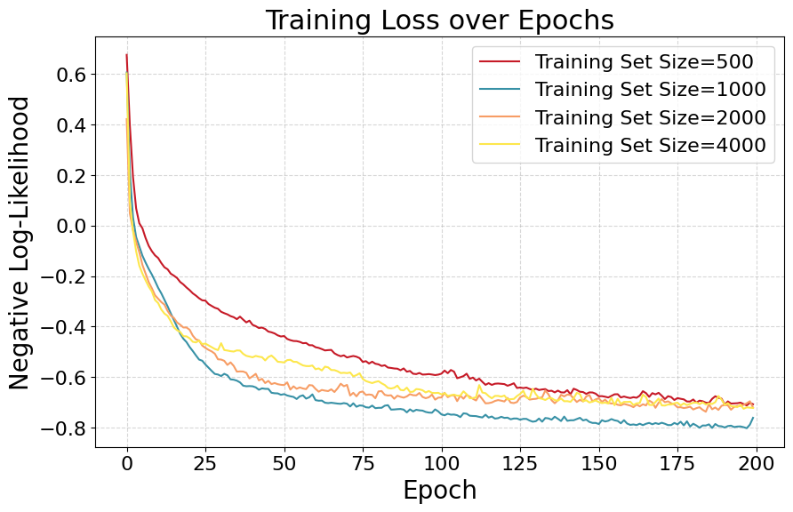

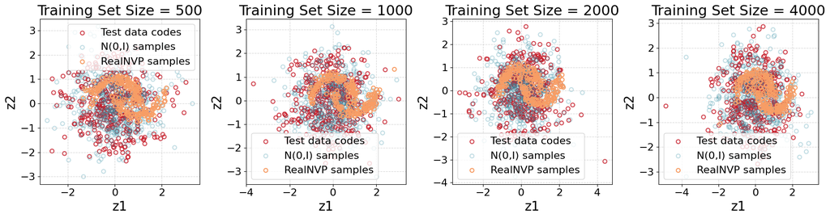

```
Mean of codes for different training set sizes:
Training Set Size 500:
 Mean = [-0.05 -0.06],
 Covariance =
 [[ 0.92 -0.03]
 [-0.03  0.96]]
Training Set Size 1000:
 Mean = [-0.11  0.01],
 Covariance =
 [[0.95 0.01]
 [0.01 0.96]]
Training Set Size 2000:
 Mean = [ 0.09 -0.02],
 Covariance =
 [[ 0.97 -0.02]
 [-0.02  0.97]]
Training Set Size 4000:
 Mean = [-0.05  0.04],
 Covariance =
 [[0.99 0.  ]
 [0.   0.96]]
```

```python
# Plot function
def plot_results(results, x_train, x_test, parameter_name, parameter_values, num_models = 4):
    # Plot negative log-likelihood on training data
    plt.figure(figsize=(10,6))
    for i, (params, losses, model) in enumerate(results):
        plt.plot(losses, label=f"{parameter_name}={parameter_values[i]}")
    plt.xlabel("Epoch")
    plt.ylabel("Negative Log-Likelihood")
    plt.title("Training Loss over Epochs")
    plt.legend()
    plt.show()

    # If num_models > 4, adjust figure subplots layout to max 4 per row
    # empty plots should be blank and no axes
    if num_models > 4:
        rows = math.ceil(num_models / 4)
        fig, axes = plt.subplots(rows, 4, figsize=(18, 5 * rows))
        axes = axes.flatten()
        for i in range(4 * rows - num_models):
            axes[-(i + 1)].axis('off')  # turn off unused axes
    else:
        fig, axes = plt.subplots(1, num_models, figsize=(18,5))


    for i in range(num_models):
        params, losses, model = results[i]
        param_value = parameter_values[i]

        # Check codes for each model
        z_test, _ = model.forward(x_test)
        z_test = z_test.detach().numpy()
        axes[i].scatter(z_test[:,0], z_test[:,1], alpha = 0.8, label="Test data codes")
        axes[i].set_title(f"Code Distribution of Test Data (Size: {param_value})")
        axes[i].set_xlabel("z1")
        axes[i].set_ylabel("z2")
        # Calculate if codes follow standard normal
        normal_samples = np.random.randn(500, 2)
        axes[i].scatter(normal_samples[:,0], normal_samples[:,1], alpha = 0.3, label="N(0,I) samples")


        # Generate samples for each model
        x_gen = model.sample(250)
        axes[i].scatter(x_gen[:,0], x_gen[:,1], label="RealNVP samples")
        axes[i].set_title(f"{parameter_name} = {param_value}")
        axes[i].legend()

    fig.tight_layout()
    plt.show()

plot_results(results_size, X_train, X_test, "Training Set Size", [size[0][0] for size in results_size])

# Calculate mean and covariance of codes
mus = []
covs = []
for params, losses, model in results_size:
    z_test, _ = model.forward(X_test)
    z_test = z_test.detach().numpy()
    mu = np.mean(z_test, axis=0)
    cov = np.cov(z_test, rowvar=False)
    mus.append(mu)
    covs.append(cov)

print("Mean of codes for different training set sizes:")
for i, params in enumerate(hyperparams_size):
    training_set_size = params[0]
    print(f"Training Set Size {training_set_size}: \n Mean = {np.round(mus[i],2)}, \n Covariance =\n {np.round(covs[i],2)}")
```

```python
#Training for different mini-batch sizes
hyperparams_batch = [
    (2000, 16,  200, 0.001, 32, 4),
    (2000, 32,  200, 0.001, 32, 4),
    (2000, 64,  200, 0.001, 32, 4),
    (2000, 128, 200, 0.001, 32, 4),
    (2000, 256, 200, 0.001, 32, 4)
]

results_batch = []

for params in hyperparams_batch:
    train_size, batch, epochs, lr, hidden, blocks = params

    print(f"\nTraining with mini-batch size = {batch}")

    model = RealNVP(input_size=2, hidden_size=hidden, blocks=blocks)

    losses = train_realnvp(model,
                           X_train,
                           training_set_size=train_size,
                           mini_batch_size=batch,
                           n_epochs=epochs,
                           learning_rate=lr)

    results_batch.append((params, losses, model))
```

```
Training with mini-batch size = 16
```

```
Training with mini-batch size = 32
```

```
Training with mini-batch size = 64
```

```
Training with mini-batch size = 128
```

```
Training with mini-batch size = 256
```

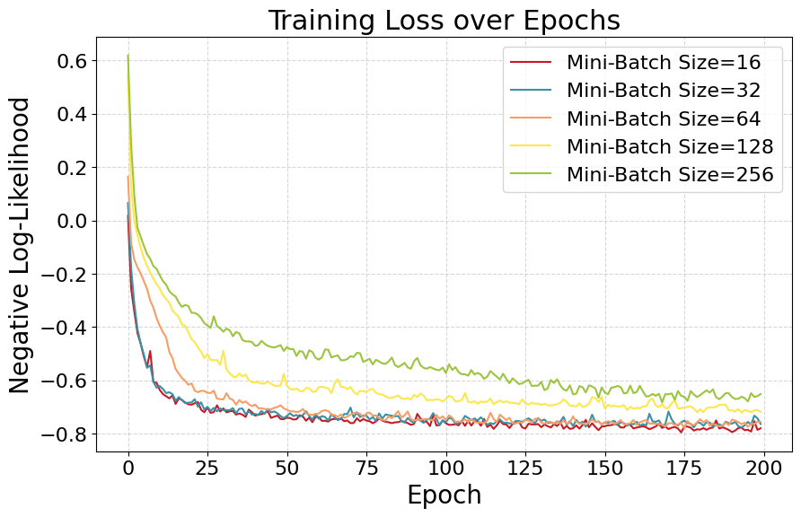

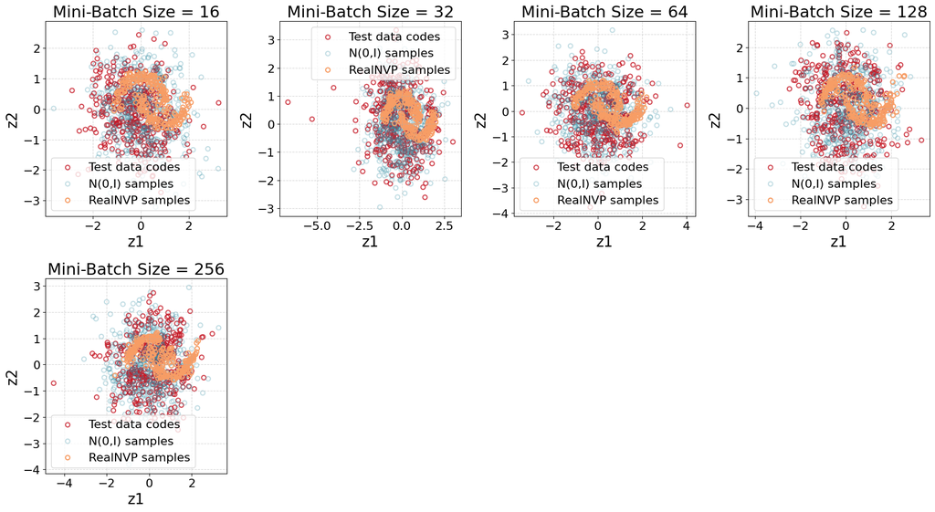

```
Mean of codes for different mini-batch sizes:
Batch size 16:
 Mean = [-0.23 -0.12],
 Covariance =
 [[ 0.88 -0.16]
 [-0.16  0.83]]
Batch size 32:
 Mean = [-0.15  0.13],
 Covariance =
 [[ 1.26 -0.18]
 [-0.18  1.06]]
Batch size 64:
 Mean = [ 0.04 -0.09],
 Covariance =
 [[ 1.04 -0.04]
 [-0.04  0.99]]
Batch size 128:
 Mean = [-0.03  0.05],
 Covariance =
 [[ 1.03 -0.11]
 [-0.11  1.09]]
Batch size 256:
 Mean = [0.1  0.04],
 Covariance =
 [[0.97 0.1 ]
 [0.1  1.  ]]
```

```python
# Plot results for mini-batch size experiments
plot_results(results_batch, X_train, X_test, "Mini-Batch Size", [size[0][1] for size in results_batch], num_models=5)

# Calculate mean and covariance of codes
mus = []
covs = []
for params, losses, model in results_batch:
    z_test, _ = model.forward(X_test)
    z_test = z_test.detach().numpy()
    mu = np.mean(z_test, axis=0)
    cov = np.cov(z_test, rowvar=False)
    mus.append(mu)
    covs.append(cov)

print("Mean of codes for different mini-batch sizes:")
for i, params in enumerate(hyperparams_batch):
    batch_size = params[1]
    print(f"Batch size {batch_size}: \n Mean = {np.round(mus[i],2)}, \n Covariance =\n {np.round(covs[i],2)}")
```

A visual inspection didn't suffice for a clear answer. The negative log-likelihood is lowest for smaller batch sizes but considering the means and covariances, we reject batch sizes smaller than 64, as they show the largest deviation from a standard normal distribution. We pick a batch-size of 64 for further tests as it appears to show the best combination of both standard distributed codes and low loss.

```python
#training with different number of blocks
hyperparams_blocks = [
    (2000, 64, 200, 0.001, 32, 2),
    (2000, 64, 200, 0.001, 32, 3),
    (2000, 64, 200, 0.001, 32, 4),
    (2000, 64, 200, 0.001, 32, 6),
    (2000, 64, 200, 0.001, 32, 8),
]

results_blocks = []

for params in hyperparams_blocks:
    train_size, batch, epochs, lr, hidden, blocks = params

    print(f"\nTraining with {blocks} RealNVP blocks")

    model = RealNVP(input_size=2, hidden_size=hidden, blocks=blocks)

    losses = train_realnvp(model,
                           X_train,
                           training_set_size=train_size,
                           mini_batch_size=batch,
                           n_epochs=epochs,
                           learning_rate=lr)

    results_blocks.append((params, losses, model))
```

```
Training with 2 RealNVP blocks
```

```
Training with 3 RealNVP blocks
```

```
Training with 4 RealNVP blocks
```

```
Training with 6 RealNVP blocks
```

```
Training with 8 RealNVP blocks
```

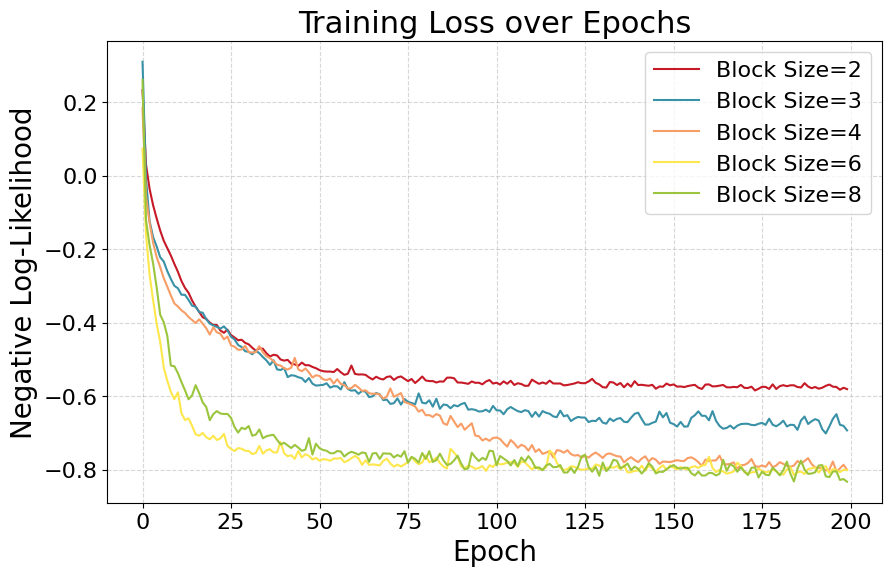

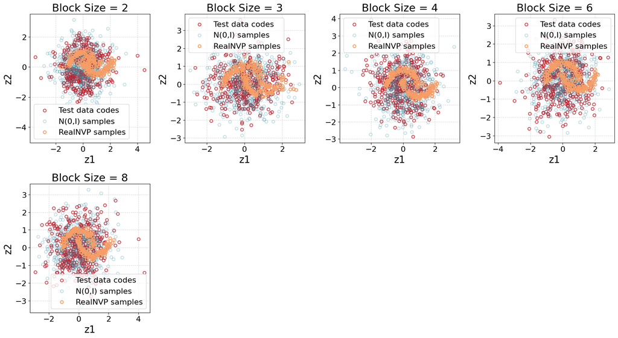

```
Mean of codes for different block sizes:
Block size 2:
 Mean = [-0.03 -0.02],
 Covariance =
 [[0.92 0.08]
 [0.08 0.94]]
Block size 3:
 Mean = [0.05 0.04],
 Covariance =
 [[0.94 0.08]
 [0.08 0.78]]
Block size 4:
 Mean = [-0.07  0.14],
 Covariance =
 [[ 0.84 -0.08]
 [-0.08  1.03]]
Block size 6:
 Mean = [-0.02  0.06],
 Covariance =
 [[0.96 0.14]
 [0.14 1.18]]
Block size 8:
 Mean = [-0.02  0.  ],
 Covariance =
 [[1.07 0.05]
 [0.05 1.07]]
```

```python
# Plot results for block size experiments
plot_results(results_blocks, X_train, X_test, "Block Size", [size[0][5] for size in results_blocks], num_models=5)

# Calculate mean and covariance of codes
mus = []
covs = []
for params, losses, model in results_blocks:
    z_test, _ = model.forward(X_test)
    z_test = z_test.detach().numpy()
    mu = np.mean(z_test, axis=0)
    cov = np.cov(z_test, rowvar=False)
    mus.append(mu)
    covs.append(cov)

print("Mean of codes for different block sizes:")
for i, params in enumerate(hyperparams_blocks):
    block_size = params[5]
    print(f"Block size {block_size}: \n Mean = {np.round(mus[i],2)}, \n Covariance =\n {np.round(covs[i],2)}")
```

Larger blocks show the smallest negative log-likelihood loss, but the means and covariances are unhelpful in deciding the best performing model. A visual inspection indicates that a block size of 8 looks best among the models we tested.

### Now training with 2 Moons at noise level 0.1

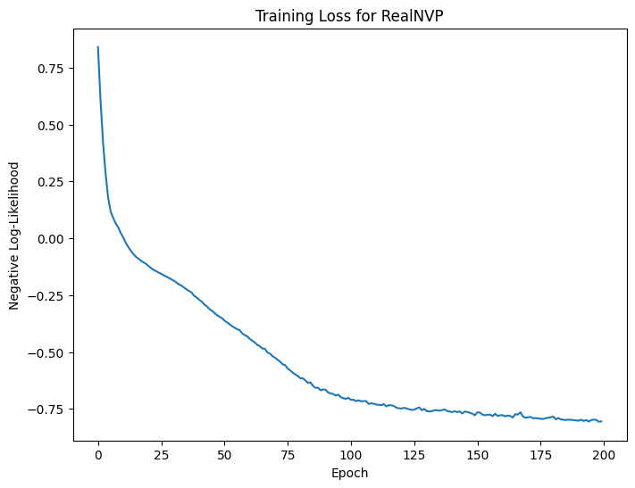

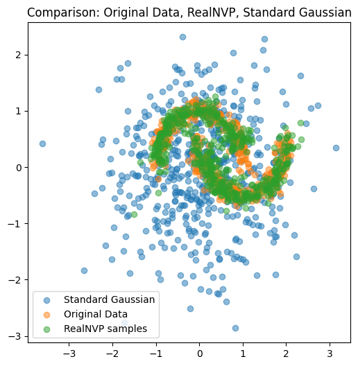

```python
X, _ = make_moons(n_samples=2000, noise=0.1)
X = torch.tensor(X, dtype=torch.float32)
X_train, X_test = train_test_split(X, test_size=0.2, shuffle=True)
model = RealNVP(input_size=2, hidden_size=32, blocks=6)


losses = train_realnvp(model,
                       X_train,
                       training_set_size=train_size,
                       mini_batch_size=batch_size,
                       n_epochs=200,
                       learning_rate=0.001)

#Plot training loss
plt.figure(figsize=(8,6))
plt.plot(losses)
plt.xlabel("Epoch")
plt.ylabel("Negative Log-Likelihood")
plt.title("Training Loss for RealNVP")
plt.show()

# Generate samples from trained model
x_gen = model.sample(500)

# Compare to standard Gaussian
z_gauss = np.random.randn(500, 2)

plt.figure(figsize=(6,6))
plt.scatter(z_gauss[:,0], z_gauss[:,1], alpha=0.5, label="Standard Gaussian")
plt.scatter(X_test[:,0], X_test[:,1], alpha=0.5, label="Original Data")
plt.scatter(x_gen[:,0], x_gen[:,1], alpha=0.5, label="RealNVP samples")
plt.title("Comparison: Original Data, RealNVP, Standard Gaussian")
plt.legend()
plt.show()
```

#### Hexagon task

```python
hyperparams_hexagon = [
    (2000, 64, 200, 0.001, 32, 8),
    (5000, 64, 200, 0.001, 64, 8),
]

def generate_hexagon_gmm(radius=1.0, points_per_cluster=300):
    angles = np.linspace(0, 2*np.pi, 6, endpoint=False)  # 6 corners
    centers = np.stack([radius*np.cos(angles), radius*np.sin(angles)], axis=1)

    X_list = []
    for c in centers:
        cluster = np.random.randn(points_per_cluster, 2) * (radius/10) + c
        X_list.append(cluster)
    X = np.vstack(X_list)
    return torch.tensor(X, dtype=torch.float32)

# Example
X_gmm = generate_hexagon_gmm(radius=1.0, points_per_cluster=300)

# Train-test split
X_train_gmm, X_test_gmm = train_test_split(X_gmm, test_size=0.2, shuffle=True)
```

```python
results_hexagon = []

for params in hyperparams_hexagon:
    train_size, batch, epochs, lr, hidden, blocks = params

    print(f"\nTraining with {hidden} RealNVP hidden size and {blocks} blocks")

    model = RealNVP(input_size=2, hidden_size=hidden, blocks=blocks)

    losses = train_realnvp(model,
                           X_train_gmm,
                           training_set_size=train_size,
                           mini_batch_size=batch,
                           n_epochs=epochs,
                           learning_rate=lr)

    results_hexagon.append((params, losses, model))
```

```
Training with 32 RealNVP hidden size and 8 blocks
```

```
Training with 64 RealNVP hidden size and 8 blocks
```

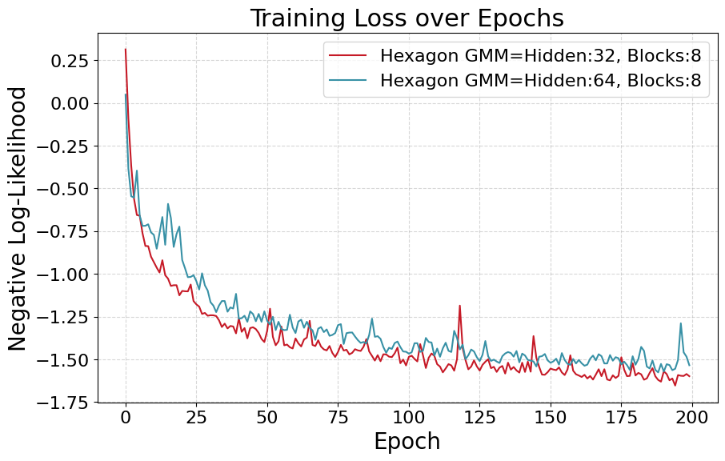

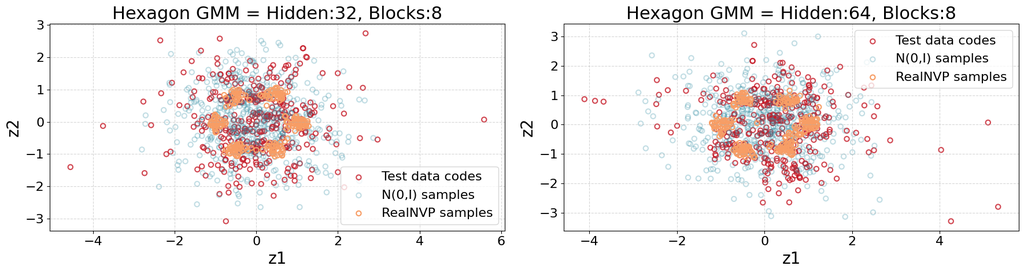

```
Mean of codes for different mini-batch sizes:
Batch size 64:
 Mean = [0.01 0.01],
 Covariance =
 [[1.01 0.02]
 [0.02 1.03]]
Batch size 64:
 Mean = [ 0.24 -0.04],
 Covariance =
 [[ 1.1  -0.16]
 [-0.16  1.04]]
```

```python
plot_results(results_hexagon, X_train_gmm, X_test_gmm, "Hexagon GMM", [f"Hidden:{size[0][4]}, Blocks:{size[0][5]}" for size in results_hexagon], num_models=2)

# Calculate mean and covariance of codes
mus = []
covs = []
for params, losses, model in results_hexagon:
    z_test, _ = model.forward(X_test_gmm)
    z_test = z_test.detach().numpy()
    mu = np.mean(z_test, axis=0)
    cov = np.cov(z_test, rowvar=False)
    mus.append(mu)
    covs.append(cov)

print("Mean of codes for different mini-batch sizes:")
for i, params in enumerate(hyperparams_hexagon):
    batch_size = params[1]
    print(f"Batch size {batch_size}: \n Mean = {np.round(mus[i],2)}, \n Covariance =\n {np.round(covs[i],2)}")
```

We can definitely see the hexagonal distribution of the data points.

## Task 2

Two Moons with a conditional invertible neural network

### Create datasets with labels

```python
# Two Moons Dataset
X, y = make_moons(n_samples=2000, noise=0.1)
X = torch.tensor(X, dtype=torch.float32)
y = torch.tensor(y, dtype=torch.float32)

# train-test split
X_Mtrain, X_Mtest, y_Mtrain, y_Mtest = train_test_split(X, y, test_size=0.2, shuffle=True)

print("Train size:", X_Mtrain.shape, y_Mtrain.shape)
print("Test size:", X_Mtest.shape, y_Mtest.shape)
```

```
Train size: torch.Size([1600, 2]) torch.Size([1600])
Test size: torch.Size([400, 2]) torch.Size([400])
```

```python
# Hexagon GMM Dataset
def generate_hex_gmm(radius=1.0, points_per_cluster=300):
    angles = np.linspace(0, 2*np.pi, 6, endpoint=False)  # 6 corners
    centers = np.stack([radius*np.cos(angles), radius*np.sin(angles)], axis=1)

    X_list = []
    y_list = []
    label = 0
    for c in centers:
        cluster = np.random.randn(points_per_cluster, 2) * (radius/10) + c
        X_list.append(cluster)
        labels = np.full(points_per_cluster, label)
        label += 1
        y_list.append(labels)
    X = np.vstack(X_list)
    y = np.hstack(y_list)
    return torch.tensor(X, dtype=torch.float32), torch.tensor(y, dtype=torch.float32)

# Example
X_hex, y_hex = generate_hex_gmm(radius=1.0, points_per_cluster=300)
print(X_hex.shape, y_hex.shape)

#Train-test split
X_Htrain, X_Htest, y_Htrain, y_Htest = train_test_split(X_hex, y_hex, test_size=0.2, shuffle=True)
```

```
torch.Size([1800, 2]) torch.Size([1800])
```

### Implement a conditional invertible neural network

```python
# One-Hot Encoding Function for the labels (conditions)
def oneHot(conds, condition_size):
    '''
    Convert labels to one-hot encoded vectors.
    ---
    y: tensor of shape ([num_samples])
    condition_size: number of categories in labels
    '''
    cond_onehot = torch.zeros(conds.size(0), condition_size)
    for i in range(conds.shape[0]):
        cond_onehot[i, int(torch.sum(conds[i]))] = 1
    return cond_onehot

# conditions in one-hot format:
c_Mtrain, c_Mtest, c_Htrain, c_Htest  = oneHot(y_Mtrain, 2), oneHot(y_Mtest, 2), oneHot(y_Htrain, 6), oneHot(y_Htest, 6)
print("Conversion to one-hot format done.")
print("Example input labels:")
print( y_Mtrain[:5])
print("One-hot encoded output:")
print(c_Mtrain[:5,:])
```

```
Conversion to one-hot format done.
Example input labels:
tensor([0., 1., 0., 0., 1.])
One-hot encoded output:
tensor([[1., 0.],
        [0., 1.],
        [1., 0.],
        [1., 0.],
        [0., 1.]])
```

```python
# Coupling Layer for RealNVP with forward and inverse methods
class CouplingLayer(nn.Module):
    def __init__(self, input_size, hidden_size, condition_size, mask):
        """
        input_size : dimension of x (2 for two moons)
        hidden_size : width of the internal networks
        condition_size : dimension of the one-hot encoded labels (conditions)
        mask : boolean tensor of shape (input_size,)
               True  -> passthrough part (x1)
               False -> transformed part (x2)
        """
        super().__init__()
        self.mask = mask
        self.condition_size = condition_size

        in_dim = int(mask.sum().item()) + condition_size
        #out_dim = 2
        out_dim = input_size - in_dim + condition_size # number of transformed dims
        # translation
        self.t_net = nn.Sequential(
            nn.Linear(in_dim, hidden_size),
            nn.ReLU(),
            nn.Linear(hidden_size, hidden_size),
            nn.ReLU(),
            nn.Linear(hidden_size, out_dim)
        )

        # scaling
        self.s_net = nn.Sequential(
            nn.Linear(in_dim, hidden_size),
            nn.ReLU(),
            nn.Linear(hidden_size, hidden_size),
            nn.ReLU(),
            nn.Linear(hidden_size, out_dim)
        )


    def forward(self, x, conds):
        """if conds.shape[0] != x.shape[0] | conds.shape[1] != self.condition_size:
            print("Conditions shape:", conds.shape)
            print("Expected size:", (x.shape[0], self.condition_size))
            raise ValueError("Shape of conditions does not match expected size.")"""

        # unchanged part (unch)
        x_masked = x[:, self.mask]
        x1 = torch.cat([x_masked,conds],dim=1)

        # transformed part (trans)
        x2 = x[:, ~self.mask]
        x2 = torch.cat([x_masked,conds],dim=1)

        t = self.t_net(x1)
        s_tilde = self.s_net(x1)
        s = torch.exp(torch.tanh(s_tilde))  # ensures positive, controlled scaling

        y2 = x2 * s + t #Transformed part including conditions

        y_conds = y2[:, x_masked.shape[1]:] # Extraction of encoded conditions

        # combine back into full coordinate vector (without conditions):
        y = x.clone()
        y[:, ~self.mask] = y2[:, :x_masked.shape[1]]

        # log-det Jacobian = sum(log(s))
        log_det = torch.sum(torch.log(s), dim=1)

        return y, y_conds, log_det

    def inverse(self, y, conds):
        # unchanged part (unch)
        y_masked = y[:, self.mask]
        y1 = torch.cat([y_masked,conds],dim=1)

        # transformed part (trans)
        #y2= y[:, ~self.mask]
        y_masked = y[:, ~self.mask]
        y2 = torch.cat([y_masked,conds],dim=1)
        #print(y1.shape, y2.shape, conds.shape)

        t = self.t_net(y1)
        s_tilde = self.s_net(y1)
        s = torch.exp(torch.tanh(s_tilde))
        #print(s.shape, "s", t.shape, "t")

        x2 = (y2 - t) / s # Transformed part including conditions

        x_conds = x2[:, y_masked.shape[1]:] # Extraction of reconstructed conditions (These are not discrete, i.e. 1.0 or 0.0, yet.)
        x_labels = x_conds.argmax(dim=1)  # Decoding to original labels
        x_conds = oneHot(x_labels, self.condition_size)  # Re-encoding to one-hot format

        # combine back into full coordinate vector (without conditions):
        x = y.clone()
        x[:, ~self.mask] = x2[:, :y_masked.shape[1]]

        log_det = -torch.sum(torch.log(s), dim=1)

        #print("Inverse CL done.")

        return x, x_conds, log_det
```

```python
#Test whether CouplingLayers work
layer = CouplingLayer(input_size=2, hidden_size=128, condition_size=2, mask=torch.tensor([True, False]))
z, z_conds, log_det = layer.forward(X_Mtrain[:5,:], c_Mtrain[:5,:])
x, x_conds, log_det = layer.inverse(z, z_conds)
```

```python
# defining the conditional Invertible Neural Network (RealNVP model):
class cINN(nn.Module):
    def __init__(self, input_size, hidden_size, condition_size, blocks, device='cpu'):
        super().__init__()
        self.input_size = input_size
        self.blocks = blocks
        self.device = device
        self.condition_size = condition_size

        # alternating masks for coupling layers (swap which half is transformed)
        masks = []
        for b in range(blocks):
            if b % 2 == 0:
                mask = torch.tensor([True, False])   # first dim passthrough
            else:
                mask = torch.tensor([False, True])   # second dim passthrough
            masks.append(mask)

        # create coupling layers for each mask
        self.couplings = nn.ModuleList([
            CouplingLayer(input_size, hidden_size, condition_size, mask)
            for mask in masks
        ])

        if blocks > 1:
            R = torch.stack([self._random_ortho(input_size) for _ in range(blocks - 1)])
            self.register_buffer("rotations", R)
        else:
            self.register_buffer("rotations", torch.empty(0))

    def _random_ortho(self, dim):
        #Create a random orthonormal matrix using QR decomposition.
        a = torch.randn(dim, dim)
        q, r = torch.qr(a)
        if torch.det(q) < 0:
            q[:, 0] = -q[:, 0]
        return q

    def forward(self, x, conds):
        #Encoder: x -> z
        y = x
        log_det_tot = torch.zeros(x.size(0), device=x.device)
        for i, c in enumerate(self.couplings):
            y, y_conds, logd = c.forward(y, conds)
            log_det_tot = log_det_tot + logd
            # apply rotation if not last block
            if i < len(self.couplings) - 1:
                R = self.rotations[i].to(x.device)
                y = (R @ y.t()).t()
        return y, y_conds, log_det_tot

    def inverse(self, z, z_conds):
        #Decoder: z -> x
        y = z
        log_det_tot = torch.zeros(z.size(0), device=z.device)
        for i in reversed(range(len(self.couplings))):
            # inverse rotation if not last in reverse
            if i < len(self.couplings) - 1:
                R = self.rotations[i].to(z.device)
                y = (R.t() @ x.t()).t()  # transpose = inverse for orthonormal
            x, x_conds, logd = self.couplings[i].inverse(y, z_conds)
            log_det_tot = log_det_tot + logd
        return x, x_conds, log_det_tot

    def sample(self, num_samples, conditions):
        #Generate samples: z ~ N(0,I) -> x
        z = torch.randn(num_samples, self.input_size, device=next(self.parameters()).device)
        z_conds = torch.tensor(conditions)[torch.randint(len(conditions), (num_samples,))]
        z_conds = oneHot(z_conds, self.condition_size).to(z.device)
        x, x_conds, _ = self.inverse(z, z_conds)
        return x.detach().cpu().numpy(), x_conds
```

```python
def train_cINN(model, X_train, c_train, training_set_size, mini_batch_size, n_epochs, learning_rate):
    optimizer = optim.Adam(model.parameters(), lr=learning_rate)
    X = torch.cat([X_train, c_train], dim=1)
    dataset = TensorDataset(X[:training_set_size])
    loader = DataLoader(dataset, batch_size=mini_batch_size, shuffle=True)

    losses = []
    label_loss = []

    for epoch in tqdm(range(n_epochs)):
        epoch_loss = 0.0
        max_recon_error = 0.0   # track worst-case inversion error
        label_err = 0.0

        for (x_batch,) in loader:
            #print("Training batch shape:", x_batch.shape)
            c_batch = x_batch[:, model.input_size:]
            x_batch = x_batch[:, :model.input_size]
            #print("x_batch:", x_batch.shape, "c_batch:", c_batch.shape)


            # forward
            z, z_conds, log_det = model.forward(x_batch, c_batch)

            # inverse consistency check
            x_reconstructed, c_reconstructed, _ = model.inverse(z, z_conds)
            batch_err = torch.max(torch.abs(x_reconstructed - x_batch)).item()
            max_recon_error = max(max_recon_error, batch_err)

            # compute loss
            log_p_z = -0.5 * torch.sum(z**2, dim=1)
            nll = -(log_p_z + log_det)
            loss = nll.mean()

            optimizer.zero_grad()
            loss.backward()
            optimizer.step()

            epoch_loss += loss.item()

            #Evaluate label reconstruction:
            label_recon = (c_batch * c_reconstructed).sum() # dot product for one-hot vectors returns 1 if correctly reconstructed and 0 if not
            label_err += label_recon / c_batch.shape[0]  # average over batch; range [0,1]; Ideally close to 1


            #print(f"Label Reconstruction Accuracy: {label_recon_err:.4f}")


        losses.append(epoch_loss / len(loader))
        label_loss.append(label_err / len(loader))

        # print diagnostics
        #print(f"Epoch {epoch+1}/{n_epochs} | Loss: {losses[-1]:.4f} | Max Recon Err: {max_recon_error:.2e} | Label Acc: {label_loss[-1]:.3f}")

    return model, losses
```

```python
TS = [X_Htrain, c_Htrain, 6]
test = [X_Htest, c_Htest, 6]
test_label = c_Htest.argmax(dim=1)

best_params = [32,6, 500,31, 200] # hidden_size, blocks, training_set_size, mini_batch_size, n_epochs

model_Hex = cINN(input_size=2, hidden_size=best_params[0], condition_size=TS[2], blocks=best_params[1])
trained_Hex, losses_Hex = train_cINN(model_Hex, TS[0], TS[1],
                                     training_set_size= best_params[2],
                                     mini_batch_size=best_params[3],
                                     n_epochs=best_params[4],
                                     learning_rate=0.001)
```

```python
#Sampling from trained model with all conditions
gen, cond_gen = trained_Hex.sample(1000, conditions=[1,2,3,4,5,0])

# Code distribution of trained model:
z, z_conds, log_det_tot = trained_Hex.forward(test[0], test[1])
# Reconstrucion from code distribution:
x_rec, x_conds_rec, log_det_tot = trained_Hex.inverse(z, z_conds)

# Adjust dtypes etc. for plotting:
z = z.detach().numpy()
x_rec = x_rec.detach().numpy()
x_conds_rec = x_conds_rec.argmax(dim=1).detach().numpy()
cond_gen = cond_gen.argmax(dim=1)
```

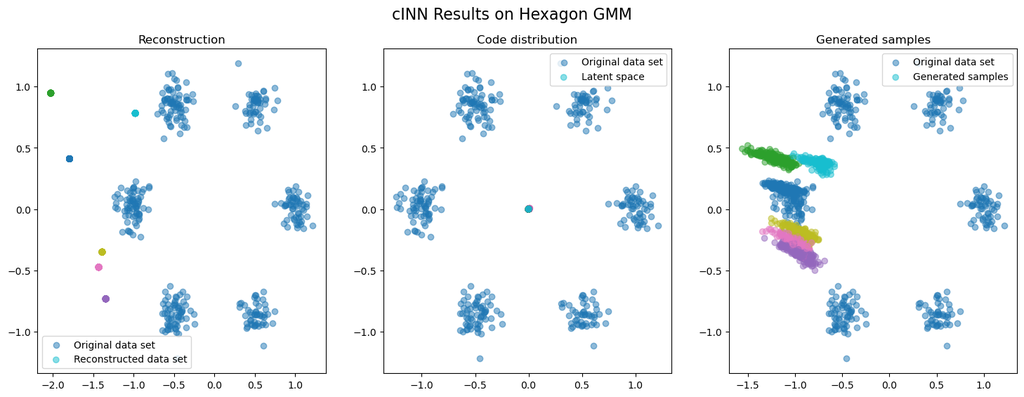

```python
fig, axes = plt.subplots(1, 3, figsize=(18,6))

#axes[0].figure(figsize=(6,6))
axes[0].scatter(test[0][:,0], test[0][:,1], alpha=0.5, label="Original data set")#, c=test_label, cmap='tab10')
axes[0].scatter(x_rec[:,0], x_rec[:,1], alpha=0.5, c=x_conds_rec, label="Reconstructed data set", cmap='tab10')
axes[0].set_title("Reconstruction")
axes[0].legend()

axes[1].scatter(test[0][:,0], test[0][:,1], alpha=0.5, label="Original data set")#, c=test_label, cmap='tab10')
axes[1].scatter(z[:,0], z[:,1], alpha=0.5, c=z_conds.argmax(dim=1).detach().numpy(), cmap='tab10', label="Latent space")
axes[1].set_title("Code distribution")
axes[1].legend()

axes[2].scatter(test[0][:,0], test[0][:,1], alpha=0.5, label="Original data set")#, c=test_label, cmap='tab10')
axes[2].scatter(gen[:,0], gen[:,1], alpha=0.5, label="Generated samples", c=cond_gen, cmap='tab10')
axes[2].set_title("Generated samples")
axes[2].legend()
plt.suptitle("cINN Results on Hexagon GMM", fontsize=16)
plt.show()
```

The conditional invertible neural network is implemented similar to the normal invertible neural network, but with the addition of labels as extra input to the coupling layers. It does not properly work yet.

```python
TS = [X_Mtrain, c_Mtrain, 2]
test = [X_Mtest, c_Mtest, 2]
test_label = c_Htest.argmax(dim=1)

best_params = [32,6, 500,31, 200] # hidden_size, blocks, training_set_size, mini_batch_size, n_epochs

model_Moons = cINN(input_size=2, hidden_size=best_params[0], condition_size=TS[2], blocks=best_params[1])
trained_Moons, losses_Moons = train_cINN(model_Moons, TS[0], TS[1],
                                     training_set_size= best_params[2],
                                     mini_batch_size=best_params[3],
                                     n_epochs=best_params[4],
                                     learning_rate=0.001)
```

```python
#Sampling from trained model with all conditions
gen, cond_gen = trained_Moons.sample(1000, conditions=[1,2,3,4,5,0])

# Code distribution of trained model:
z, z_conds, log_det_tot = trained_Moons.forward(test[0], test[1])
# Reconstrucion from code distribution:
x_rec, x_conds_rec, log_det_tot = trained_Moons.inverse(z, z_conds)

# Adjust dtypes etc. for plotting:
z = z.detach().numpy()
x_rec = x_rec.detach().numpy()
x_conds_rec = x_conds_rec.argmax(dim=1).detach().numpy()
cond_gen = cond_gen.argmax(dim=1)
```

[output not shown]

[figure not shown]

```python
fig, axes = plt.subplots(1, 3, figsize=(18,6))

#axes[0].figure(figsize=(6,6))
axes[0].scatter(test[0][:,0], test[0][:,1], alpha=0.5, label="Original data set")#, c=test_label, cmap='tab10')
axes[0].scatter(x_rec[:,0], x_rec[:,1], alpha=0.5, c=x_conds_rec, label="Reconstructed data set", cmap='tab10')
axes[0].set_title("Reconstruction")
axes[0].legend()

axes[1].scatter(test[0][:,0], test[0][:,1], alpha=0.5, label="Original data set")#, c=test_label, cmap='tab10')
axes[1].scatter(z[:,0], z[:,1], alpha=0.5, c=z_conds.argmax(dim=1).detach().numpy(), cmap='tab10', label="Latent space")
axes[1].set_title("Code distribution")
axes[1].legend()

axes[2].scatter(test[0][:,0], test[0][:,1], alpha=0.5, label="Original data set")#, c=test_label, cmap='tab10')
axes[2].scatter(gen[:,0], gen[:,1], alpha=0.5, label="Generated samples", c=cond_gen, cmap='tab10')
axes[2].set_title("Generated samples")
axes[2].legend()
plt.suptitle("cINN Results on Two Moons", fontsize=16)
plt.show()
```

## 3. Higher-dimensional data with an INN

We repeat Task 1 with the digits dataset. The codes are therefore 8x8 -> 64 dimensional. Plotting different 2D projections we can see if they are normally distributed.

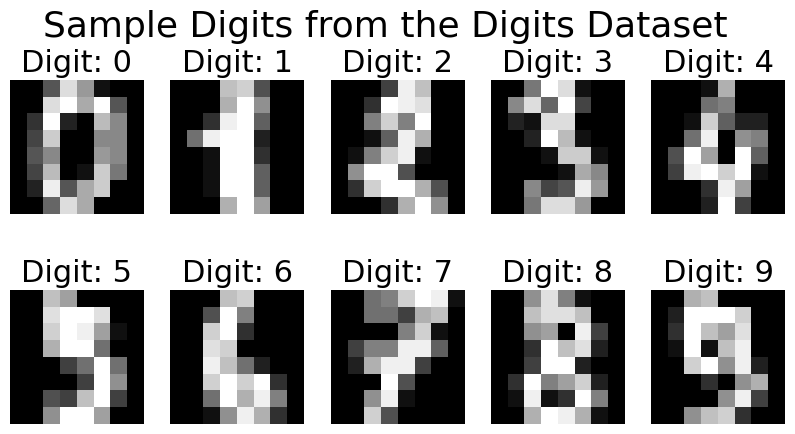

```python
# Digits dataset
from sklearn.datasets import load_digits
digits = load_digits()
X_digits = digits.data  # shape (n_samples, 64)
X_digits = torch.tensor(X_digits, dtype=torch.float32)
X_digits = X_digits.view(-1, 8, 8)  # reshape to (n_samples, 8, 8)

# Plot some examples
fig, axes = plt.subplots(2, 5, figsize=(10,5))
for i in range(10):
    ax = axes[i//5, i%5]
    ax.imshow(X_digits[i].numpy(), cmap='gray')
    ax.axis('off')
    ax.set_title(f"Digit: {digits.target[i]}")
plt.suptitle("Sample Digits from the Digits Dataset")
plt.show()

# Split into train and test
X_train_digits, X_test_digits = train_test_split(X_digits, test_size=0.2, shuffle=True)
# Flatten for training
X_train_digits = X_train_digits.view(-1, 64)
X_test_digits = X_test_digits.view(-1, 64)
```

```python
#Training for different training set sizes
hyperparams_network = [
    (6000, 128, 250, 0.001, 128, 4),
    (6000, 128, 250, 0.001, 128, 6),
    (6000, 128, 250, 0.001, 256, 6),
    (6000, 128, 250, 0.001, 256, 8),
]

results_digits_network = []

for params in hyperparams_network:
    train_size, batch, epochs, lr, hidden, blocks = params

    print(f"\nTraining with network dimensions = hidden:{hidden}, blocks:{blocks}")
    model = RealNVP(input_size=64, hidden_size=hidden, blocks=blocks)
    losses = train_realnvp(model,
                           X_train_digits,
                           training_set_size=train_size,
                           mini_batch_size=batch,
                           n_epochs=epochs,
                           learning_rate=lr)

    results_digits_network.append((params, losses, model))
```

```
Training with network dimensions = hidden:128, blocks:4
```

```
Training with network dimensions = hidden:128, blocks:6
```

```
Training with network dimensions = hidden:256, blocks:6
```

```
Training with network dimensions = hidden:256, blocks:8
```

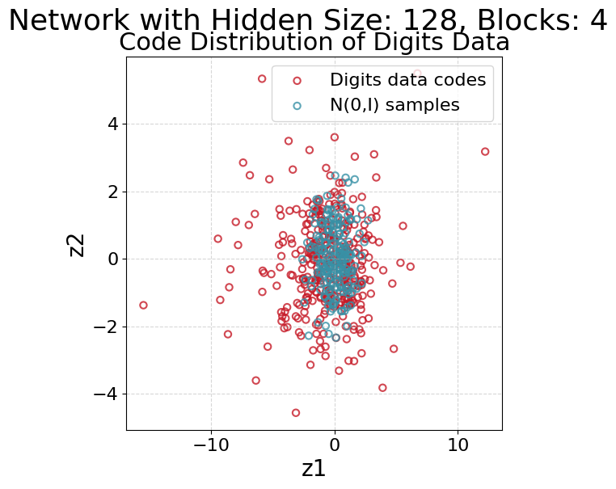

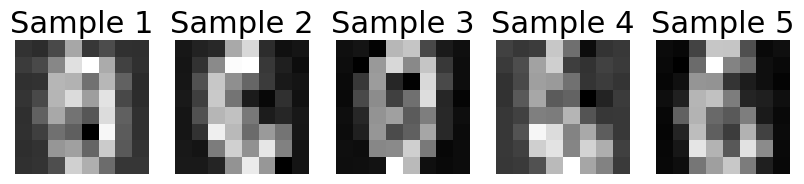

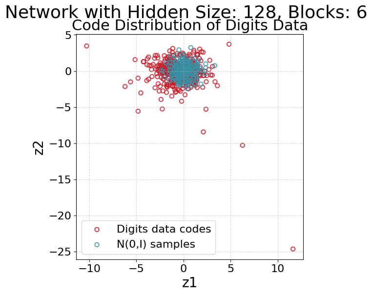

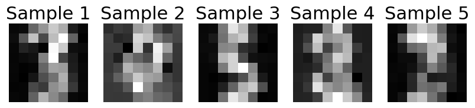

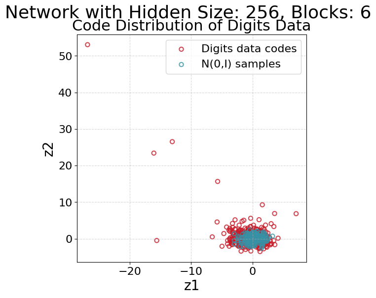

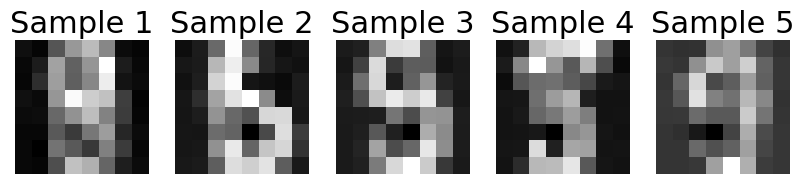

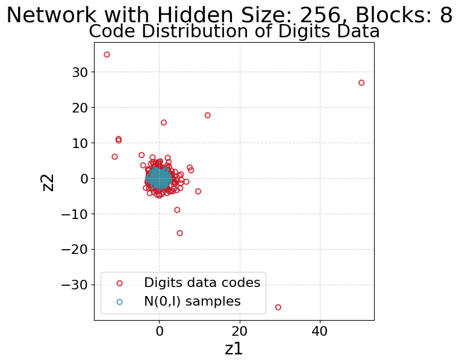

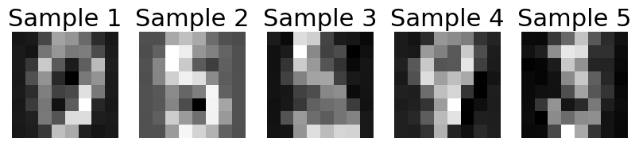

```python
# Check codes for each model
for i in range(len(results_digits_network)):
    params, losses, model = results_digits_network[i]
    param_value = params[0]

    # Check codes for each model, check two random dimensions
    dim1, dim2 = np.random.choice(64, size=2, replace=False)
    z_test, _ = model.forward(X_test_digits)
    z_test = z_test.detach().numpy()
    plt.figure(figsize=(6,6))
    plt.suptitle(f"Network with Hidden Size: {params[4]}, Blocks: {params[5]}")
    plt.scatter(z_test[:,dim1], z_test[:,dim2], alpha = 0.8, label="Digits data codes")
    plt.title(f"Code Distribution of Digits Data")
    plt.xlabel("z1")
    plt.ylabel("z2")
    # Calculate if codes follow standard normal
    normal_samples = np.random.randn(200, 2)
    plt.scatter(normal_samples[:,0], normal_samples[:,1], alpha = 0.8, label="N(0,I) samples")
    plt.legend()
    plt.show()

    # Generate samples for each model
    x_gen = model.sample(250)
    # Reshape to 8x8 for visualization
    x_gen_reshaped = x_gen.reshape(-1, 8, 8)
    plt.figure(figsize=(10,5))
    for j in range(5):
        ax = plt.subplot(1, 5, j+1)
        ax.imshow(x_gen_reshaped[j], cmap='gray')
        ax.axis('off')
        ax.set_title(f"Sample {j+1}")
    #plt.suptitle(f"Generated Samples from RealNVP (Training Size: {param_value})")
    plt.show()
    #plt.scatter(x_gen[:,0], x_gen[:,1], label="RealNVP samples")
    #plt.title(f"Training Set Size = {param_value}")
    #plt.legend()
    #plt.show()
```

This already shows promising results, i.e. there are structures beyond simply noisy images, but they cannot yet be recognized as digits.